# Pre-processing

David Anglada Rotger and Andreu Huguet Segarra

4/30/2019

## 1. Data load and variables

We will begin with loading the complete dataset “Medical Appointment No Shows” from the Kaggle website. That collects information about which patients show up or don’t show up when making an appointment.

```r
# DIR <- 'W://AA1/'
DIR <- 'C://Users/Administrador 2/Desktop/AA1/'
setwd(DIR)
dd <- read.csv(paste(DIR, "hospital.csv", sep=""),
               encoding = 'UTF-8')
```

```r
if(!exists("foo", mode="function")) source("functions.R")
colnames(dd)
```

```
##  [1] "PatientId"      "AppointmentID"  "Gender"         "ScheduledDay"
##  [5] "AppointmentDay" "Age"            "Neighbourhood"  "Scholarship"
##  [9] "Hipertension"   "Diabetes"       "Alcoholism"     "Handcap"
## [13] "SMS_received"   "No.show"
```

```r
head(dd)
```

```
##      PatientId AppointmentID Gender         ScheduledDay
## 1 2.987250e+13       5642903      F 2016-04-29T18:38:08Z
## 2 5.589978e+14       5642503      M 2016-04-29T16:08:27Z
## 3 4.262962e+12       5642549      F 2016-04-29T16:19:04Z
## 4 8.679512e+11       5642828      F 2016-04-29T17:29:31Z
## 5 8.841186e+12       5642494      F 2016-04-29T16:07:23Z
## 6 9.598513e+13       5626772      F 2016-04-27T08:36:51Z
##         AppointmentDay Age     Neighbourhood Scholarship Hipertension
## 1 2016-04-29T00:00:00Z  62   JARDIM DA PENHA           0            1
## 2 2016-04-29T00:00:00Z  56   JARDIM DA PENHA           0            0
## 3 2016-04-29T00:00:00Z  62     MATA DA PRAIA           0            0
## 4 2016-04-29T00:00:00Z   8 PONTAL DE CAMBURI           0            0
## 5 2016-04-29T00:00:00Z  56   JARDIM DA PENHA           0            1
## 6 2016-04-29T00:00:00Z  76         REPÚBLICA           0            1
##   Diabetes Alcoholism Handcap SMS_received No.show
## 1        0          0       0            0      No
## 2        0          0       0            0      No
## 3        0          0       0            0      No
## 4        0          0       0            0      No
## 5        1          0       0            0      No
## 6        0          0       0            0      No
```

# 1.1. Variable transformation and relabeling

# 1.1.1. Factoritzation of the binary variables

```r
dd$PatientId <- factor(dd$PatientId, levels = unique(dd$PatientId))
dd$Gender <- factor(dd$Gender, levels = unique(dd$Gender))

dd$No.show <- factor(dd$No.show,
                         levels = unique(dd$No.show),
                         labels = c("Show", "NoShow"))

dd$Scholarship <- factor(dd$Scholarship,
                         levels = unique(dd$Scholarship),
                         labels = c("No", "Yes"))

dd$Hipertension <- factor(dd$Hipertension,
                          levels = unique(dd$Hipertension),
                          labels = c("Yes", "No"))

dd$Diabetes <- factor(dd$Diabetes,
                      levels = unique(dd$Diabetes),
                      labels = c("No", "Yes"))

dd$Alcoholism <- factor(dd$Alcoholism,
                        levels = unique(dd$Alcoholism),
                        labels = c("No", "Yes"))

dd$Handcap <- factor(dd$Handcap,
                     levels = unique(dd$Handcap),
                     labels = c("None", "Low", "Mid", "High", "VHigh"))

dd$SMS_received <- factor(dd$SMS_received,
                          levels = unique(dd$SMS_received),
                          labels = c("No", "Yes"))
```

# 1.1.2. Neighbourhood encoding

We also might think of encoding the neighbourhoods with shorter, but still recognizable, labels.

```r
neighbourhoods <- levels(dd$Neighbourhood)
short.neighbourhoods <- encodeNeighbourhood(neighbourhoods)
# Remove last element (which is blank)
short.neighbourhoods <- short.neighbourhoods[-length(short.neighbourhoods)]
```

The encoding has been successful since there are still 81 unique values.

```r
length(unique(short.neighbourhoods))
```

```
## [1] 81
```

```r
length(neighbourhoods)
```

```
## [1] 81
```

So we can apply the encoding.

```r
dd$Neighbourhood <- factor(dd$Neighbourhood, labels = short.neighbourhoods)
```

# 1.1.3. Date transformation

Another big problem we see is the treatment of the dates of appointment because the format hard to interpret. This calls for a transformation of the variables and opens a window for the creation of new variables containing interesting relations with the dates.

```r
DYM <- getDYM(dd$ScheduledDay)

dd$SchedDay <- as.numeric(DYM$day)
dd$SchedMonth <- as.numeric(DYM$month)
dd$SchedYear <- as.numeric(DYM$year)

HM <- getHM(dd$ScheduledDay)

dd$SchedHour <- as.numeric(HM$hour)
dd$SchedMinute <- as.numeric(HM$minute)
```

And we can do the same to the variable $\texttt{AppointmentDay}$.

```r
DYM <- getDYM(dd$AppointmentDay)

dd$AppointDay <- as.numeric(DYM$day)
dd$AppointMonth <- as.numeric(DYM$month)
dd$AppointYear <- as.numeric(DYM$year)
```

Since the old variables are of no use no more, we can choose to erase them.

```r
dd$ScheduledDay <- NULL
dd$AppointmentDay <- NULL
```

We can also create an interesting, although natural, variable consisting of the difference of days between the scheduled date and the appointment date.

```r
dd$DateDiff <- dateDiff(dd)
```

# 1.2 Anomaly detection

We now want to erase or fix any possible anomaly that can cause erronious predictions. We first will assume that the variables $\texttt{Gender}$, $\texttt{Neighbourhoood}$, $\texttt{Scholarship}$, $\texttt{Hipertension}$, $\texttt{Diabetes}$, $\texttt{Alcoholism}$, $\texttt{Handcap}$, $\texttt{SMS_received}$, $\texttt{No.show}$ do not contain any anomaly since they are of type factor and we have checked that the $\texttt{unique}$ vector is the same as the levels we would want to have.

# 1.2.1 Missing values

To begin with, we will check if there are any missing values in the dataset. First, we look at the $\texttt{Age}$ variable. We see that there is a patient that is -1 years old. We proceed to remove that instance.

```r
range(unique(dd$Age))
```

```
## [1]  -1 115
```

```r
dd <- dd[-which(dd$Age == -1),]
```

In the documentation of the data set it is clear that the appointment date is always after the scheduled date but we see a minimum value of $-6$ in DateDiff. Let’s check these anomalies.

```r
dd[which(dd$DateDiff < 0),]
```

```
##             PatientId AppointmentID Gender Age Neighbourhood Scholarship
## 27034   7839272661752       5679978      M  38        RENCIA          No
## 55227   7896293967868       5715660      F  19        SAÔNIO          No
## 64176  24252258389979       5664962      F  22        COAÇÃO          No
## 71534 998231581612122       5686628      F  81        SAÔNIO          No
## 72363   3787481966821       5655637      M   7        TAEIRO          No
##       Hipertension Diabetes Alcoholism Handcap SMS_received No.show
## 27034           No       No         No     Low           No  NoShow
## 55227           No       No         No     Low           No  NoShow
## 64176           No       No         No    None           No  NoShow
## 71534           No       No         No    None           No  NoShow
## 72363           No       No         No    None           No  NoShow
##       SchedDay SchedMonth SchedYear SchedHour SchedMinute AppointDay
## 27034       10          5      2016        10          51          9
## 55227       18          5      2016        14          50         17
## 64176        5          5      2016        13          43          4
## 71534       11          5      2016        13          49          5
## 72363        4          5      2016         6          50          3
##       AppointMonth AppointYear DateDiff
## 27034            5        2016       -1
## 55227            5        2016       -1
## 64176            5        2016       -1
## 71534            5        2016       -6
## 72363            5        2016       -1
```

Other than two of these five patients being of Handcap level 1, these are pretty standard patients all having fled their appointment in the month of May 2016… Maybe these no shows have been caused by the problem of the switched date. We choose to erase these instances since they are not representative of the general behaviour of the patients.

```r
dd <- dd[-which(dd$DateDiff < 0),]
```

# 1.3 Deletion of irrelevant variables

We now might want to see if there are variables that don’t add any additional information and disturb the interpretability of the model proposed. We will begin with the two $\texttt{ID}$ variables.

Firstly, we would want to know if patients come back to the hospital. That is, that there are multiple visits of patients.

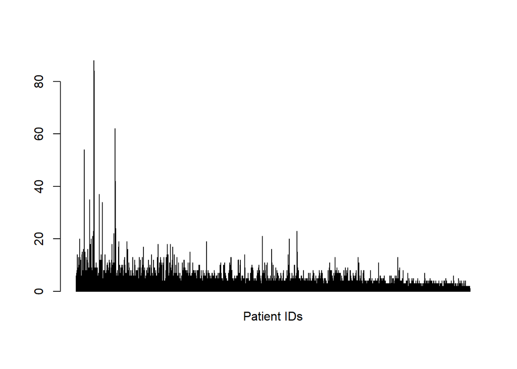

```r
barplot(table(dd$PatientId), names.arg = "Patient IDs")
```

Definitely! There are patients that come back very regulary. So this might bring us important and personalized predictions of the patients.

Unsurprisingly, the appointment ID will be unique. But we would like to know if its related to the date of appointment or schedule.

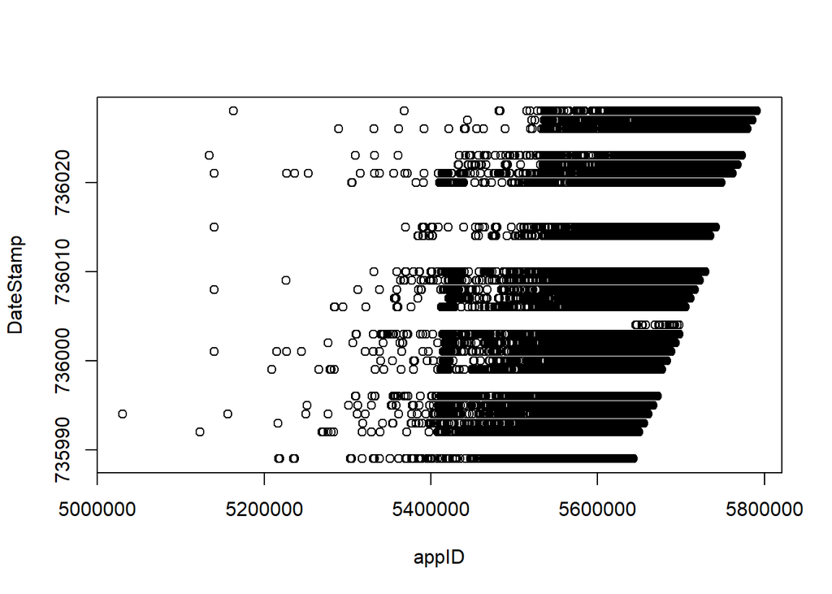

```r
# DateStamp = Days + Months*30 + Years*365
SchedStamp <- dd$SchedDay + dd$SchedMonth*30 + dd$SchedYear*365
DateStamp <- dd$AppointDay + dd$AppointMonth*30 + dd$AppointYear*365

appID <- as.numeric(dd$AppointmentID)

plot(appID, DateStamp)
```

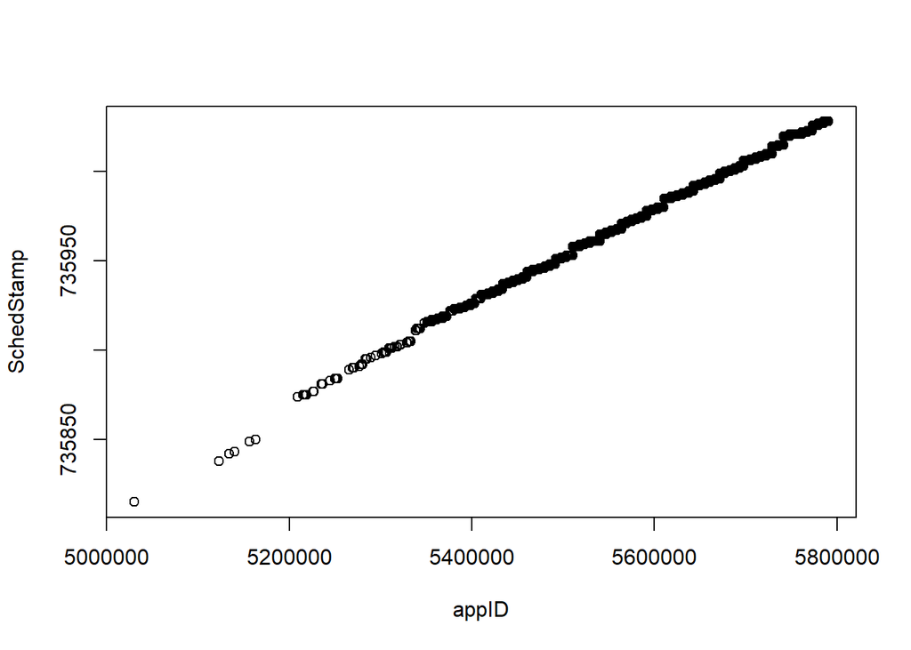

```r
plot(appID, SchedStamp)
```

We suspect that it is the case. We will calculate the $R^2$ of the relation $\texttt{AppointmentID}$ and $\texttt{SchedStamp}$.

```r
mod <- glm(appID ~ SchedStamp)
Rsquared <- 1 - mod$deviance/mod$null.deviance
summary(mod)
```

```
##
## Call:
## glm(formula = appID ~ SchedStamp)
##
## Deviance Residuals:
##    Min      1Q  Median      3Q     Max
## -13955   -2311     482    2787   53118
##
## Coefficients:
##               Estimate Std. Error t value Pr(>|t|)
## (Intercept) -2.767e+09  5.088e+05   -5437   <2e-16 ***
## SchedStamp   3.767e+03  6.913e-01    5449   <2e-16 ***
## ---
## Signif. codes:  0 '***' 0.001 '**' 0.01 '*' 0.05 '.' 0.1 ' ' 1
##
## (Dispersion parameter for gaussian family taken to be 18853998)
##
##     Null deviance: 5.6180e+14  on 110520  degrees of freedom
## Residual deviance: 2.0837e+12  on 110519  degrees of freedom
## AIC: 2165123
##
## Number of Fisher Scoring iterations: 2
```

```r
Rsquared
```

```
## [1] 0.996291
```

The $R^2$ show that there is a very strong correlation between the two variables. Therefore, we will erase the $\texttt{AppointmentID}$ variable for simplicity.

```r
dd$AppointmentID <- NULL
summary(dd)
```

```
##            PatientId      Gender         Age         Neighbourhood
##  822145925426128:    88   F:71836   Min.   :  0.00   JABURI : 7717
##  99637671331    :    84   M:38685   1st Qu.: 18.00   MARTIZ : 5805
##  26886125921145 :    70             Median : 37.00   RENCIA : 4430
##  33534783483176 :    65             Mean   : 37.09   JAENHA : 3877
##  258424392677   :    62             3rd Qu.: 55.00   ITRARÉ : 3514
##  871374938638855:    62             Max.   :115.00   CENTRO : 3334
##  (Other)        :110090                              (Other):81844
##  Scholarship Hipertension Diabetes     Alcoholism    Handcap
##  No :99660   Yes:21801    No :102578   No :107161   None :108282
##  Yes:10861   No :88720    Yes:  7943   Yes:  3360   Low  :  2040
##                                                     Mid  :   183
##                                                     High :    13
##                                                     VHigh:     3
##
##
##  SMS_received   No.show         SchedDay       SchedMonth
##  No :75039    Show  :88207   Min.   : 1.00   Min.   : 1.000
##  Yes:35482    NoShow:22314   1st Qu.: 6.00   1st Qu.: 4.000
##                              Median :13.00   Median : 5.000
##                              Mean   :14.25   Mean   : 4.824
##                              3rd Qu.:22.00   3rd Qu.: 5.000
##                              Max.   :31.00   Max.   :12.000
##
##    SchedYear      SchedHour      SchedMinute   AppointDay    AppointMonth
##  Min.   :2015   Min.   : 6.00   Min.   : 0   Min.   : 1.0   Min.   :4.00
##  1st Qu.:2016   1st Qu.: 8.00   1st Qu.:14   1st Qu.: 5.0   1st Qu.:5.00
##  Median :2016   Median :10.00   Median :29   Median :10.0   Median :5.00
##  Mean   :2016   Mean   :10.77   Mean   :29   Mean   :12.5   Mean   :5.21
##  3rd Qu.:2016   3rd Qu.:13.00   3rd Qu.:44   3rd Qu.:19.0   3rd Qu.:5.00
##  Max.   :2016   Max.   :21.00   Max.   :59   Max.   :31.0   Max.   :6.00
##
##   AppointYear      DateDiff
##  Min.   :2016   Min.   :  0.00
##  1st Qu.:2016   1st Qu.:  0.00
##  Median :2016   Median :  4.00
##  Mean   :2016   Mean   : 10.04
##  3rd Qu.:2016   3rd Qu.: 14.00
##  Max.   :2016   Max.   :181.00
##
```

```r
# Export processed data to file
write.csv(dd, file = paste(DIR, 'data.csv', sep = "/"))
```